# Experiment-2 Speech Processing

## Name: Jay Goyal Roll No: C017 Btech EXTC Experiment-2

Expt 2.

Aim:

Record a speech file of 2 sec with sampling frequency of 8kHz and plot it.

Frame the recorded speech with frame length of 10/20 ms without overlap. Calculate the frame length and the number of frames.

Frame the recorded speech with frame length of 10/20 ms with an overlap of 25%and 50%. Calculate the frame length and the number of frames.

Applying Hamming window on speech frames and analyse the frames

```python
from scipy import signal
from scipy.io import wavfile
from IPython.display import Audio
import numpy as np
import matplotlib.pyplot as plt
import sounddevice as sd
```

Recording

```python
duration = 2 #No of seconds
fs = 8000
seq = sd.rec(int(duration * fs), samplerate=fs, channels=1) # Speech processing is fun
```

```python
sd.play(seq, fs)
```

```python
wavfile.write('test.wav',fs,seq)
```

Defining a sequence of 6000 to 9000

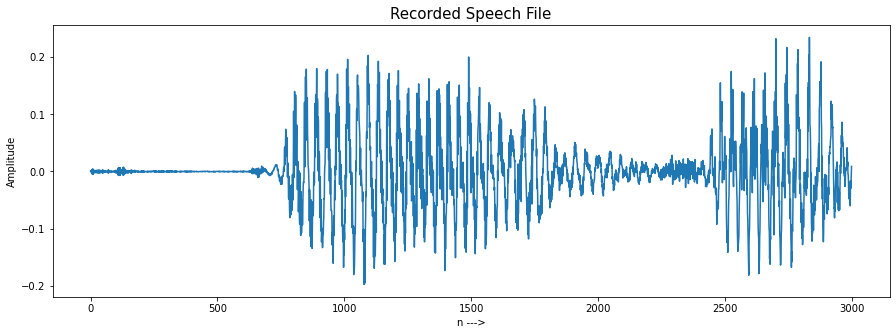

```python
plt.figure(figsize=(15,5))
plt.plot(seq[6000:9000])
plt.title("Recorded Speech File",size=15)
plt.xlabel("n --->")
plt.ylabel("Amplitude")
```

Defining a sequence of 6500 to 7000

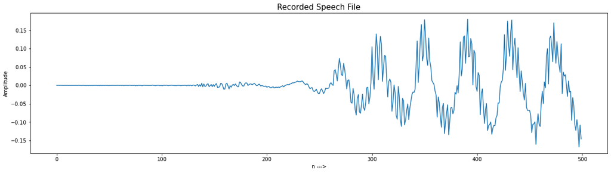

```python
plt.figure(figsize=(20,5))
plt.plot(seq[6500:7000])
plt.title("Recorded Speech File",size=15)
plt.xlabel("n --->")
plt.ylabel("Amplitude")
```

Plotting the entire sequence

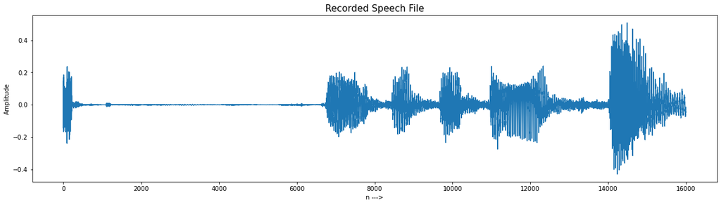

```python
plt.figure(figsize=(20,5))
plt.plot(seq)
plt.title("Recorded Speech File",size=15)
plt.xlabel("n --->")
plt.ylabel("Amplitude")
```

Theoretically when we calcluated the total samples it is 2 sec * sampling frequency 8khz which is equal to 16000. So our Theoretical result and practical result matches.

## Taking Frame as 10

```python
TL=len(seq)
print('Total length of the speech signal (in samples) is: ',TL)
f1=input('Enter frame length in milli sec: \n')
print('Frame length of the speech signal (in ms) is: ',f1)
FL=float(f1)*10**-3*fs
print('Frame length of the speech signal (in samples) is: ',int(FL))
```

```
Total length of the speech signal (in samples) is:  16000
Enter frame length in milli sec:
10
Frame length of the speech signal (in ms) is:  10
Frame length of the speech signal (in samples) is:  80
```

## Taking Percentage as 25

```python
ov=input("Enter overlap percentage :")
OV=float(ov)*FL/100
print('Overlap length (in samples) is :', int(OV))
```

```
Enter overlap percentage :25
Overlap length (in samples) is : 20
```

```python
FS=FL-OV
print('Frame shift (in samples) is: ',int(FS))
```

```
Frame shift (in samples) is:  60
```

```python
NF=TL/FL
print('Number of Frames without overlap is: ',int(NF))
NF_ov=TL/FS
print('Number of Frames with overlap is: ',int(NF_ov))
```

```
Number of Frames without overlap is:  200
Number of Frames with overlap is:  266
```

## Taking Frame as 20

```python
TL=len(seq)
print('Total length of the speech signal (in samples) is: ',TL)
f1=input('Enter frame length in milli sec: \n')
print('Frame length of the speech signal (in ms) is: ',f1)
FL=float(f1)*10**-3*fs
print('Frame length of the speech signal (in samples) is: ',int(FL))
```

```
Total length of the speech signal (in samples) is:  16000
Enter frame length in milli sec:
20
Frame length of the speech signal (in ms) is:  20
Frame length of the speech signal (in samples) is:  160
```

## Taking Percentage as 50

```python
ov=input("Enter overlap percentage :")
OV=float(ov)*FL/100
print('Overlap length (in samples) is :', int(OV))
```

```
Enter overlap percentage :50
Overlap length (in samples) is : 80
```

```python
FS=FL-OV
print('Frame shift (in samples) is: ',int(FS))
```

```
Frame shift (in samples) is:  80
```

```python
NF=TL/FL
print('Number of Frames without overlap is: ',int(NF))
NF_ov=TL/FS
print('Number of Frames with overlap is: ',int(NF_ov))
```

```
Number of Frames without overlap is:  100
Number of Frames with overlap is:  200
```

```python
import numpy as np
```

```python
ss=np.array(seq)
F1=np.resize(ss,(int(NF_ov),int(FL)))
F1.shape
```

```
(200, 160)
```

```python
ff=np.array(seq)
F2=np.resize(ss,(int(NF),int(FL)))
F2.shape
```

```
(100, 160)
```

```
Without overlap: [[ 0.14678955  0.06121826 -0.14483643 ... -0.03735352  0.14685059
   0.11633301]
 [ 0.04238892 -0.18701172  0.11209106 ... -0.01901245  0.01956177
   0.00112915]
 [-0.00085449  0.00085449 -0.00799561 ... -0.00030518  0.00195312
  -0.00402832]
 ...
 [-0.040802   -0.05474854 -0.06512451 ... -0.03466797 -0.04055786
  -0.04153442]
 [-0.04632568 -0.04452515 -0.04541016 ...  0.0607605   0.07141113
   0.06454468]
 [ 0.06143188  0.07382202  0.06378174 ... -0.02844238 -0.02706909
  -0.01467896]]
With overlap: [[ 0.14678955  0.06121826 -0.14483643 ... -0.03735352  0.14685059
   0.11633301]
 [ 0.04238892 -0.18701172  0.11209106 ... -0.01901245  0.01956177
   0.00112915]
 [-0.00085449  0.00085449 -0.00799561 ... -0.00030518  0.00195312
  -0.00402832]
 ...
 [-0.040802   -0.05474854 -0.06512451 ... -0.03466797 -0.04055786
  -0.04153442]
 [-0.04632568 -0.04452515 -0.04541016 ...  0.0607605   0.07141113
   0.06454468]
 [ 0.06143188  0.07382202  0.06378174 ... -0.02844238 -0.02706909
  -0.01467896]]
```

[figure not shown]

```python
plt.figure(figsize=(10,16))
plt.subplot(3,1,1)
print("Without overlap:",F2)
plt.title("Number of Frames without overlap")
plt.plot(F1)
plt.xlabel("n --->")
plt.ylabel("Amplitude")
plt.subplot(3,1,2)
print("With overlap:",F1)
plt.title("Number of Frames with overlap")
plt.plot(F2)
plt.xlabel("n --->")
plt.ylabel("Amplitude")
```

## Hamming Window Graph

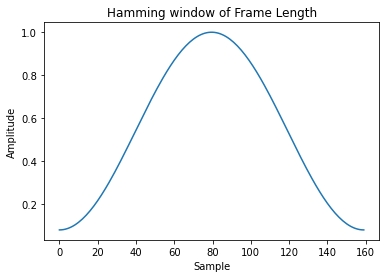

```python
from scipy import signal
from scipy.fftpack import fft, fftshift
window = signal.hamming(int(FL))
plt.plot(window)
plt.title("Hamming window of Frame Length")
plt.ylabel("Amplitude")
plt.xlabel("Sample")
plt.figure()
```

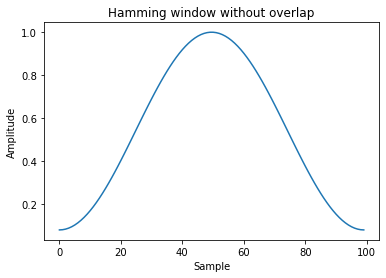

```python
from scipy import signal
from scipy.fftpack import fft, fftshift
window = signal.hamming(int(NF))
plt.plot(window)
plt.title("Hamming window without overlap")
plt.ylabel("Amplitude")
plt.xlabel("Sample")
plt.figure()
```

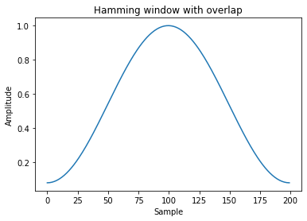

```python
from scipy import signal
from scipy.fftpack import fft, fftshift
window = signal.hamming(int(NF_ov))
plt.plot(window)
plt.title("Hamming window with overlap")
plt.ylabel("Amplitude")
plt.xlabel("Sample")
plt.figure()
```